# Composition Analysis of Dutch National Library dated 2025-12-02

# Overall summary

5,635,528 records and 424,375,836 attribute values in total. Constituent files:

- data/kbnl/kbnl.parquet (1.35GB)

## Temporal overview

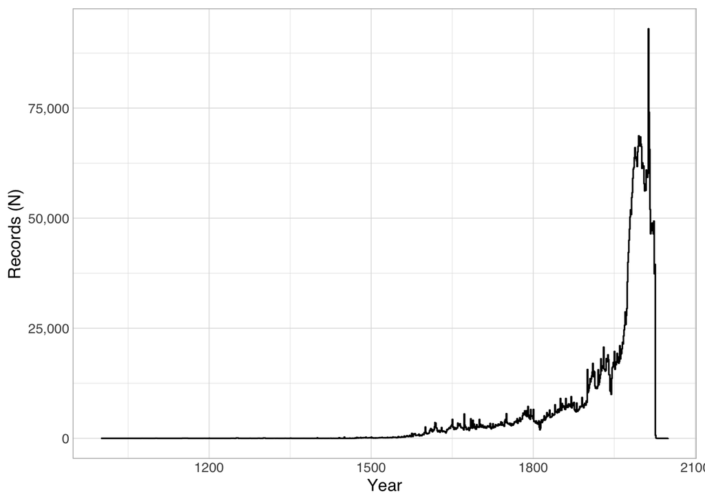

185,262 records do not have easily parseable dates between the years 1000 and 2050.

## Language overview

| [] | Records (N) | Proportion (%) |
| --- | --- | --- |
| ned | 3355161 | 0.578046884502643 |
| eng (English) | 879602 | 0.151543009620788 |
| dui | 455415 | 0.0784615766294885 |
| fra | 394682 | 0.0679981379341475 |
| lat (Latin) | 231044 | 0.0398056201723341 |
| NA | 177232 | 0.0305345720918229 |
| zxx (No linguistic content; Not applicable) | 50656 | 0.00872731382528764 |
| ita (Italian) | 43972 | 0.00757575496536537 |
| spa (Spanish; Castilian) | 33102 | 0.00570300738796335 |
| fri | 18955 | 0.00326567896316976 |

[output cut: 340 more lines]

# Field code usage overview

In total, 326 distinct fields are used.

Legend for the table below:

- `records`: how many records have at least one of this field
- `r_p`: the above as a percentage of all records
- `n`: the total number of appearances of this field
- `vals_per_rec`: calculated from the above, the mean number of appearances of this field per record
- `recs_with_mult_vals`: the number of records that have more than one repetition of this field

| field_code | field_description | records | r_p | n | vals_per_rec | recs_with_mult_vals |
| --- | --- | --- | --- | --- | --- | --- |
| <a name="001@" href="https://support.oclc.org/ggc/richtlijnen/?id=12&ln=nl&sec=k-0000">001@</a> | ILN-bits, supplier code a.o. | 5620783 | 0.997383563705122 | 5630192 | 1.00167396606487 | 9409 |
| <a name="001A" href="https://support.oclc.org/ggc/richtlijnen/?id=12&ln=nl&sec=k-0200">001A</a> | Source and date of creation | 5635528 | 1 | 5635528 | 1 | 0 |
| <a name="001B" href="https://support.oclc.org/ggc/richtlijnen/?id=12&ln=nl&sec=k-0210">001B</a> | Source and date of the last transaction | 5635528 | 1 | 11271056 | 2 | 5635528 |
| <a name="001D" href="https://support.oclc.org/ggc/richtlijnen/?id=12&ln=nl&sec=k-0230">001D</a> | Source and date of owner | 5635523 | 0.999999112771687 | 5635523 | 1 | 0 |
| <a name="001M">001M</a> | NA | 13734 | 0.0024370387300001 | 13734 | 1 | 0 |
| <a name="001P" href="https://support.oclc.org/ggc/richtlijnen/?id=12&ln=nl&sec=k-000U">001P</a> | Data for open URL | 1 | 1.77445662589202e-07 | 4 | 4 | 1 |
| <a name="001Q" href="https://support.oclc.org/ggc/richtlijnen/?id=12&ln=nl&sec=k-000Q">001Q</a> | Validation warnings | 4577 | 0.000812168797670777 | 19212 | 4.19750928555823 | 4577 |
| <a name="001R">001R</a> | NA | 592 | 0.000105047832252808 | 7076 | 11.9527027027027 | 592 |
| <a name="001U" href="https://support.oclc.org/ggc/richtlijnen/?id=12&ln=nl&sec=k-000K">001U</a> | Characterset | 5635528 | 1 | 5635528 | 1 | 0 |
| <a name="001X" href="https://support.oclc.org/ggc/richtlijnen/?id=12&ln=nl&sec=k-000A">001X</a> | Owner main record | 5635528 | 1 | 16107321 | 2.85817424738197 | 4838637 |

[output cut: 316 more lines]

# Field code usage overview by subfield

In total, 1,144 distinct field+subfield combinations are used.

Legend for the table below:

- `records`: how many records have at least one of this field+subfield
- `r_p`: the above as a percentage of all records
- `dist_vals`: the number of different values appearing in this field+subfield
- `e_vals`: at most seven random sample values of this field+subfield
- `n`: the total number of appearances of this field+subfield
- `vals_per_rec`: calculated from the above, the mean number of appearances of this field+subfield per record
- `recs_with_mult_vals`: the number of records that have more than one repetition of this field+subfield

| subfield_code | subfield_description | records | r_p | dist_vals | e_vals | n | vals_per_rec | recs_with_mult_vals |
| --- | --- | --- | --- | --- | --- | --- | --- | --- |
| [001@: ILN-bits, supplier code a.o.](https://support.oclc.org/ggc/richtlijnen/?id=12&ln=nl&sec=k-0000) |  |  |  |  |  |  |  |  |
| 001@$0 | ILN-bits, userbits | 5,620,686 | 99.74% | 765,831 | 1-4,10,22,27,169,179,225 (2)\|2-3,7,10,22,49 (1)\|2,22,160-161,180,266,283,446 (1)\|4-5,27,186,192 (2)\|1-3,5-7,10-11,49,191 (1)\|1-3,7,11,16,19,22,27 (2)\|1-3,5,31 (35) | 5,620,686 | 1 | 0 |
| 001@$a | Supplier code | 25 | 0% | 2 | @ (4)\|7 (21) | 25 | 1 | 0 |
| 001@$b | Identification in PiCarta of Online Contents journal | 9,481 | 0.17% | 1 | 5 (9,481) | 9,481 | 1 | 0 |
| [001A: Source and date of creation](https://support.oclc.org/ggc/richtlijnen/?id=12&ln=nl&sec=k-0200) |  |  |  |  |  |  |  |  |
| 001A$0 | Source and date | 5,635,528 | 100% | 246,140 | 0003:09-03-87 (102)\|1009:25-09-00 (5)\|1995:16-01-04 (14)\|1028:01-07-99 (3)\|1066:28-01-92 (4)\|1995:16-06-94 (23)\|1123:08-01-02 (6) | 5,635,528 | 1 | 0 |
| [001B: Source and date of the last transaction](https://support.oclc.org/ggc/richtlijnen/?id=12&ln=nl&sec=k-0210) |  |  |  |  |  |  |  |  |
| 001B$0 | Source and date | 5,635,528 | 100% | 43,317 | 1013:06-10-23 (7)\|1099:27-05-19 (1)\|0499:18-07-18 (42)\|1079:25-03-21 (1)\|1338:10-04-17 (1)\|1066:19-12-19 (1)\|1144:24-09-25 (1) | 5,635,528 | 1 | 0 |
| 001B$t | Timestamp | 5,635,528 | 100% | 86,471 | 10:31:10.000 (84)\|00:02:03.000 (61)\|20:42:55.000 (67)\|00:36:06.000 (54)\|04:18:23.000 (32)\|01:45:52.000 (27)\|20:25:20.000 (81) | 5,635,528 | 1 | 0 |
| [001D: Source and date of owner](https://support.oclc.org/ggc/richtlijnen/?id=12&ln=nl&sec=k-0230) |  |  |  |  |  |  |  |  |
| 001D$0 | Source and date | 5,635,523 | 100% | 126,463 | 1995:13-06-06 (40)\|1023:09-09-13 (1)\|1003:18-05-09 (192)\|1003:07-04-94 (148)\|1882:15-09-06 (10)\|1003:30-03-14 (4)\|1076:22-09-15 (3) | 5,635,523 | 1 | 0 |
| 001M: NA |  |  |  |  |  |  |  |  |
| 001M$0 | NA | 13,734 | 0.24% | 1 | 0500 (13,734) | 13,734 | 1 | 0 |
| [001P: Data for open URL](https://support.oclc.org/ggc/richtlijnen/?id=12&ln=nl&sec=k-000U) |  |  |  |  |  |  |  |  |
| 001P$0 | Type of document | 1 | 0% | 1 | PDF (1) | 1 | 1 | 0 |
| 001P$a | Supplier code | 1 | 0% | 1 | c (1) | 1 | 1 | 0 |
| 001P$d | Start of period | 1 | 0% | 1 | 1998 (1) | 1 | 1 | 0 |
| 001P$h | Code organization / department (supplier) | 1 | 0% | 1 | 1828 (1) | 1 | 1 | 0 |
| [001Q: Validation warnings](https://support.oclc.org/ggc/richtlijnen/?id=12&ln=nl&sec=k-000Q) |  |  |  |  |  |  |  |  |
| 001Q$a | Input date of tag | 4,577 | 0.08% | 808 | 11-08-08 (9)\|17-07-07 (1)\|02-06-08 (2)\|09-01-07 (1)\|08-04-14 (1)\|15-12-08 (1)\|22-11-19 (1) | 4,803 | 1.05 | 226 |
| 001Q$b | Source (e.g. external library number) | 4,577 | 0.08% | 73 | 1079 (34)\|0500 (81)\|1007 (8)\|1287 (1)\|1010 (15)\|1737 (6)\|1826 (34) | 4,803 | 1.05 | 226 |
| 001Q$c | Message number (in validation) | 4,577 | 0.08% | 4 | 17 (373)\|37 (228)\|75 (3,979)\|14 (223) | 4,803 | 1.05 | 226 |
| 001Q$d | Message text (in validation) | 4,577 | 0.08% | 135 | 'Disney's DuckTales' in 4150 moet '@' bevatten (1)\|'Software stoomcursus' in 4170 moet '@' bevatten (1)\|'Vertellingen voor één nacht' in 4170 moet '@' bevatten (1)\|'Gezondheidssleutels' in 4170 moe… | 4,803 | 1.05 | 226 |
| 001R: NA |  |  |  |  |  |  |  |  |
| 001R$a | NA | 592 | 0.01% | 592 | 2021-09-04 20:23:29 (3)\|2022-07-01 12:16:54 (1)\|2022-08-17 15:16:17 (1)\|2021-05-07 15:12:17 (4)\|2021-03-11 08:32:56 (4)\|2021-06-30 10:16:28 (3)\|2021-06-16 15:35:20 (3) | 1,769 | 2.99 | 450 |
| 001R$b | NA | 592 | 0.01% | 3 | ??? (15)\|NLNIO (1,681)\|NLVRD (73) | 1,769 | 2.99 | 450 |
| 001R$c | NA | 592 | 0.01% | 1 | error (1,769) | 1,769 | 2.99 | 450 |
| 001R$d | NA | 592 | 0.01% | 127 | Not authorized to change Date Entered on File (008/00-05) to 041112. (1)\|Mismatch on 040 $b between input record and WorldCat record (1)\|Search execution error Resource Unavailable (2)\|Not authoriz… | 1,769 | 2.99 | 450 |
| [001U: Characterset](https://support.oclc.org/ggc/richtlijnen/?id=12&ln=nl&sec=k-000K) |  |  |  |  |  |  |  |  |
| 001U$0 | NA | 5,635,528 | 100% | 1 | utf8 (5,635,528) | 5,635,528 | 1 | 0 |

[output cut: 1440 more lines]